# Activity 6: Leading your own data analysis

Heather Kropp

#### *ENVST 206: Intro to Environmental Data, Hamilton College*

## Learning objectives

#### 1. Learn data wrangling basics

#### 2. Learn to work with data independently

#### 3. Formulate an objective and outcomes for your analysis

#### 4. Get started on your class project so that you can get feedback

## Activity instructions

There are two parts to this activity. The first part contains prompts/questions for in-class coding activities. In-class coding workshops will consist of demos, live-coding, and group work. The in-class section of this activity contributes to your course participation grade. You should comment sections of your Rscript with the in-class and homework sections. In some future activities, in-class coding can help you with your homework, and thus it should be in the same script. If you finish the in-class section early, you can start working on homework with your classmates.

### *The `dplyr` package*

As you start to work with real world data, you will want to stregthen your coding skills in handling and organizing data. Install the `dplyr` package using the `install.packages` function. This package has many useful functions for working with data.

```r
install.packages(dplyr)
```

Load the package to your environment.

```r
library(dplyr)
```

```r
table1 <- read.csv("/cloud/project/activity06/table 1.csv")
table2 <- read.csv("/cloud/project/activity06/table 1.csv")
table3 <- read.csv("/cloud/project/activity06/table 1.csv")
```

### *Joining tables*

Joining two tables based on a column or columns of common identifiers between the tables. The functions for joins in R are `left_join`, `right_join`, `inner_join`, and `full_join`. You can refer to the slides in class for a reminder of the difference between these joins. The format for the each type of join is as follows:

```r
left_join(left.table,#table to be considered left table
          right.table, # table to be considered right table
          by=c("ID")) # column or columns to do the join
```

Notice how the by column just needs the column name in quotes. The `dplyr` package often uses different *syntax* than base R. In this package you won’t have to refer to a dataframe name as often. We’ll learn more about some of the other functions and ways of coding in dplyr in future classes.

For our agricultural tables, a join based on counties will look like this:

```r
counties <- full_join(table1,table2, by="county")
```

#### **Prompt 1**

Calculate the proportion of cows to people in each upstate county.

#### **Prompt 2**

Investigate if counties with more cows also have higher acreage of each type of grain harvested. Make a plot to investigate this relationship.

## Homework instructions

Save your answers in word document that you will hand in on Blackboard using a *.pdf* or *.docx* extension. Your R script should include a comment with question numbers above sections of code that relate to that question. For questions that can be answered entirely in code, you can put “see code” next to the question number in your answers word document. Download your R script from RStudio Cloud (instructions below) and upload it to Blackboard with your answers. This activity is worth 30 points.

#### **Question 1**

Describe the environmental data topic or issue you would like to cover in your project. What concept(s) from this course where you would like to focus on improving your understanding through a course project?

#### **Question 2**

Write a question, hypothesis, or objective you would like to address in your project analysis. Your analysis should be able to address the focus with existing data that you can readily access

#### **Question 3**

Describe the data that you plan to use in your analysis. Include a link to the data if applicable.

#### **Question 4**

Provide brief summary statistics (mean and standard deviation) for a part of your data. Make a plot that summarizes a component of your data.

#### **Question 5**

Outline the components of your project workflow and analysis that you anticipate. What statistical analysis do you think will be appropriate to address your main area of focus? What problems or roadblocks do you anticipate in your analysis?

### *Uploading data to RStudio Cloud*

You can add data into RStudio Cloud using the upload button:

[figure not shown]

Once you hit upload, you will see a button where you can choose a file.

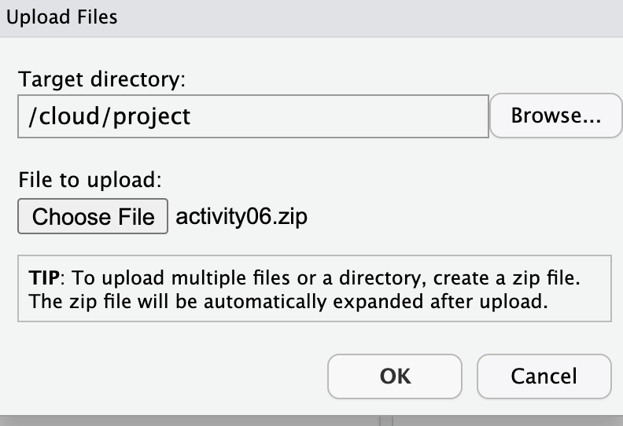